# Distribuições de probabilidade

André Stephanou

13/10/2020

```r
library(tidyverse)
```

# *Distribuições discretas*

## Degenerada

Eu quis começar com essa porque tem o melhor nome de todas. Ela sofre desse nome porque é a distribuição das variáveis que só tem um evento possível. Se lançarmos um dado com 6 faces iguais infinitas vezes, teremos uma distribuição com média igual ao número representado no dado e variância = 0.

## Uniforme discreta

Quando uma variável discreta encontra o caminho do bem e apresenta mais de um valor possível, ela vai ter uma distribuição uniforme discreta *se cada valor tem a mesma probabilidade de ocorrer*. Portanto, moedas e dados justos vão gerar distribuições uniformes discretas com sucessivos lançamentos. Nesse caso a média da distribuição é encontrada pela seguinte fórmula: $Media=\frac{k + 1}{2}$ , sendo k = número de valores possíveis. A variância será igual à $Var = \frac{1}{12}(k^2-1)$

No R, podemos simular essa distribuição com:

```r
set.seed(19)
uni_disc <- sample(x = c(1:6), # valores possíveis
       replace = TRUE, #amostragem com reposição, mantém as probabilidades sempre iguais
       prob = rep(1/6,6), #probabilidade dos 6 valores igual à 1/6
       size = 1000) %>% as.factor() #n de 1000 e as.factor porque não é contínua
table(uni_disc)
```

```
## uni_disc
##   1   2   3   4   5   6
## 177 175 146 166 164 172
```

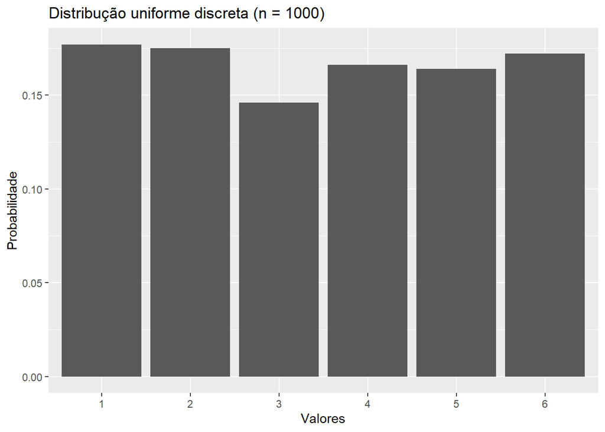

```r
ggplot() +  geom_bar(aes(x = uni_disc,
                         y = (..count..)/sum(..count..))) +
  labs(title = "Distribução uniforme discreta (n = 1000)",
       x = "Valores",
       y = "Probabilidade")
```

```r
# Como k = 6, a média tem que ser igual à
(6+1)/2
```

```
## [1] 3.5
```

```r
#ou
uni_disc %>% as.numeric %>% mean()
```

```
## [1] 3.481
```

```r
#Já a variância deve ser
1/12*(6^2-1)
```

```
## [1] 2.916667
```

```r
#ou
uni_disc %>% as.numeric %>% var()
```

```
## [1] 3.024664
```

Dá pra aumentar o tamanho amostral e os valores observados vão se aproximar cada vez mais dos valores teóricos.

## Distribuição de Bernoulli

É a distribuição de uma variável com dois resultados possíveis. Se considerarmos que cada equipe na Copa do Mundo de 2018 tinha chances iguais de vencer a competição, a probabilidade do Brasil ser campeão era de 1/32, ou 0.03125. Já a chance do Brasil não ser campeão era de 31/32 = 0.96875, ou 1 - 0.03125. A média de uma distribuição de Bernoulli vai ser sempre igual à probabilidade do evento alvo *x* ocorrer. No caso do Brasil vencer essa Copa super nivelada, p(x) = 0.03125. Já a variância é calculada por $p(1-p)$, ou seja, o produto da probabilidade do Brasil vencer e da probabilidade do Brasil não vencer. Nesse caso, temos: 0.0302734.

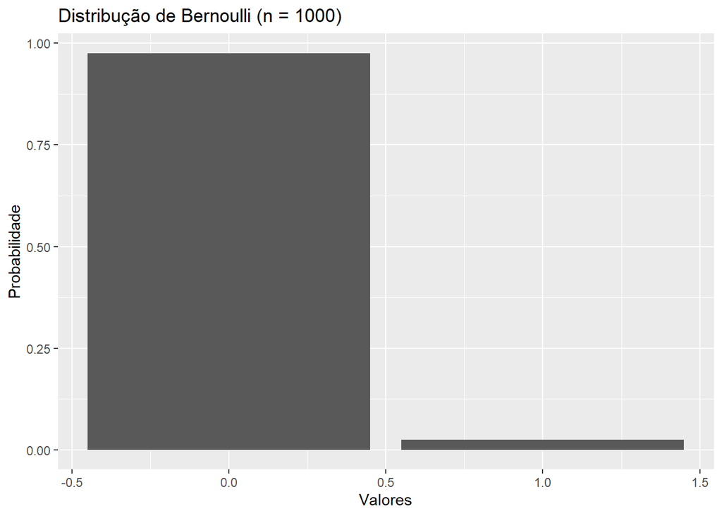

```r
set.seed(2018)
bernoulli_copa <- sample(x = c(1,0),
      prob = c(1/32,31/32),
      replace = TRUE,
      size = 1000)
ggplot() +  geom_bar(aes(x = bernoulli_copa,
                         y = (..count..)/sum(..count..))) +
  labs(title = "Distribução de Bernoulli (n = 1000)",
       x = "Valores",
       y = "Probabilidade")
```

## Distribuição binomial

Vimos que em uma Copa do Mundo equilibrada, com 32 países, o Brasil precisaria de muita sorte para conseguir um título em 21 edições exatamente iguais. Na desequilibrada vida real, o Brasil tem 5 títulos em 21 edições nada equilibradas. Mas qual a probabilidade disso acontecer em 21 edições de Copa equilibrada? É isso que a distribuição binomial representa: a probabilidade de observarmos o evento de interesse *x* vezes em *n* repetições.

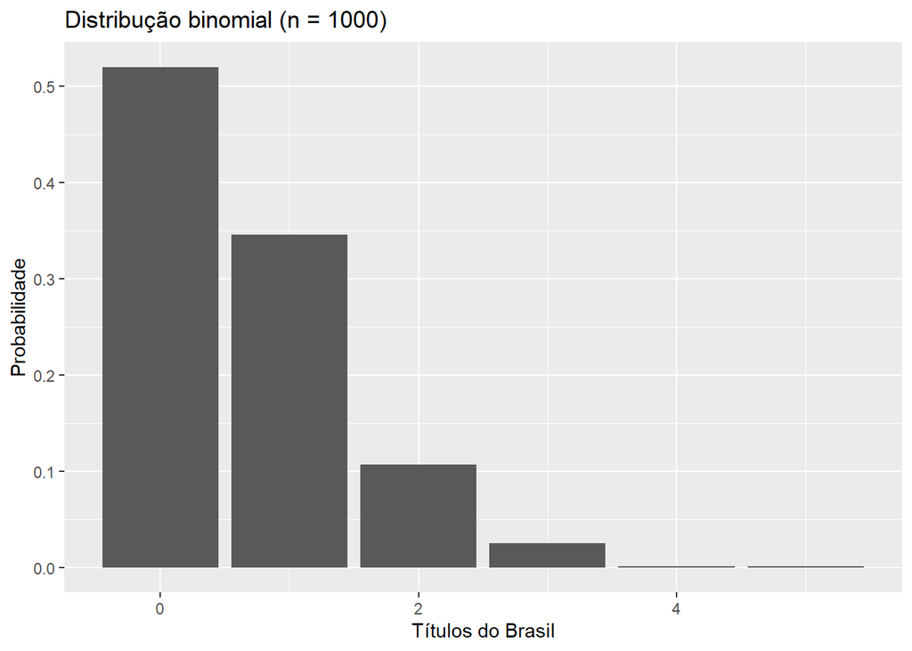

```r
binom_copa <- rbinom(n=1000,size = 21,prob = 1/32)
ggplot() + geom_bar(aes(x= binom_copa,
                        y = (..count..)/sum(..count..))) +
  labs(title = "Distribução binomial (n = 1000)",
       x = "Títulos do Brasil",
       y = "Probabilidade")
```

```r
multinom_copa <- rmultinom(n=1000,size = 21,prob = c(14/32,5/32,5/32,5/32,3/32)) %>%  t() %>% data.frame()
colnames(multinom_copa) <- c("EUR","AMS","AFR","ASI","ACN")
```

# Distribuições contínuas

Passamos então para as distribuições de variáveis contínuas. Essas distribuições tratam de variáveis infinatamente fracionáveis, então é impossível associar uma probabilidade a um valor específico. Portanto, as probabilidades tratam de intervalos de valores. Vamos ver as seguintes distribuições: uniforme contínua e normal.

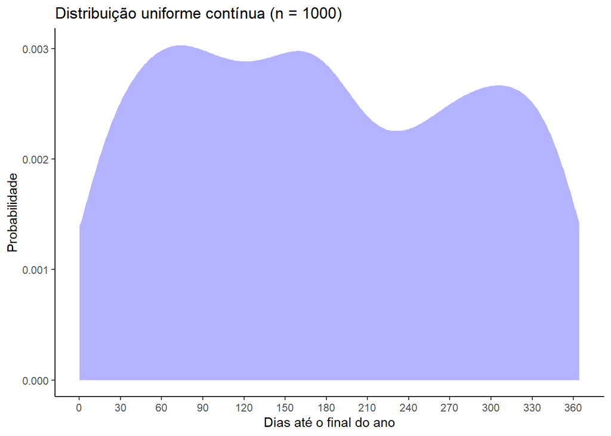

```r
unif_dist <- runif(1000,0,365)
ggplot() + geom_density(aes(unif_dist), fill = "blue", color = "white", alpha = 0.3) +
  theme_classic() +
  scale_x_continuous(breaks = seq(0,365,30)) +
  labs (title = "Distribuição uniforme contínua (n = 1000)", x = "Dias até o final do ano", y = "Probabilidade")
```

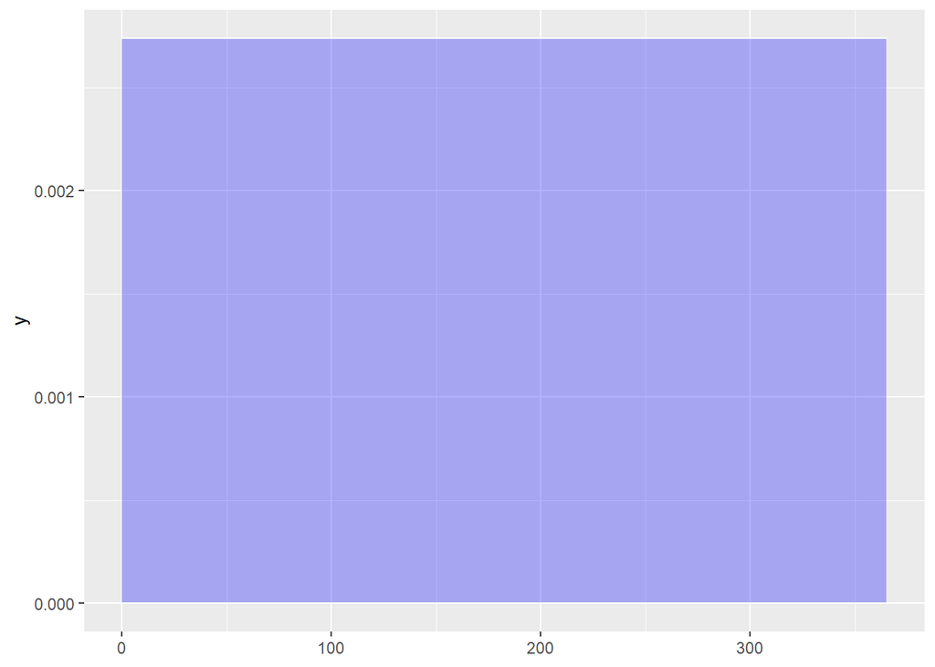

```r
ggplot() + stat_function(fun = dunif, args = list(min = 0, max = 365), xlim=c(0, 365), geom = "density", fill = "blue", alpha = .3, color = "white")
```

## Distribuição normal

Finalmente, a distribuição mais famosa, com vários nomes e histórias de origem. A distribuição normal (ou Gaussiana, ou em formato de sino) é caracterizada pela simetria em torno da média, mediana, e moda. A distribuição normal padrão tem média $\mu=0$ e variância $\sigma^2=1$. É muito usada na *padronização* de testes psicológicos.

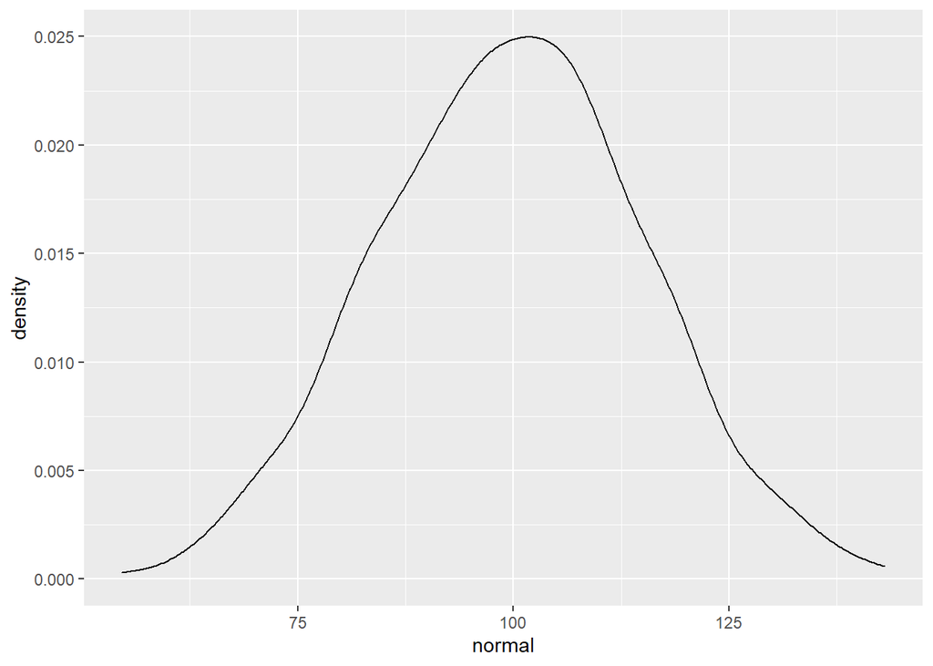

```r
set.seed(19)
normal <- rnorm(n = 500,
                mean = 100,
                sd = 15)
ggplot() + geom_density(aes(x = normal))
```

[figure not shown]

```r
ggplot() +  stat_function(fun = dnorm, args = list(mean = 100, sd = 15), xlim = c(40,160),  geom = "area", fill = "blue", alpha = .3, color = "white") +
  theme_classic() +
  scale_x_continuous(breaks = seq(40,160,15)) +
  labs (title = "Distribuição normal padrão", x = "Z", y = "Probabilidade")
```

# Distribuições amostrais

As distribuições de qui-quadrado ($\chi^2$), *t* e *F* também são conhecidas como distribuições amostrais. Vamos ver uma delas de cada vez.

## Distribuição de $\chi^2$

Quando temos das ou mais variáveis com distribuições normais, a soma dos quadrados dessas distribuições produz uma distribuição $\chi^2$. Essa distribuição não é simétrica, tendo 0 como limite inferior - quadrados não formam números negativos!

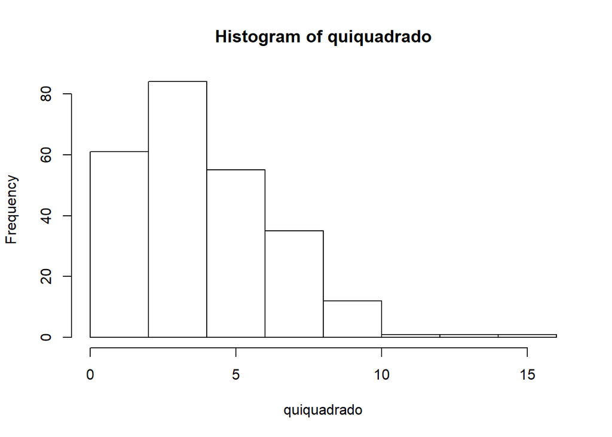

```r
set.seed(19)
norm1 <- rnorm(250,0,1)
norm2 <- rnorm(250,0,1)
norm3 <- rnorm(250,0,1)
norm4 <- rnorm(250,0,1)
norm1^2 + norm2^2 + norm3^2 + norm4^2 -> quiquadrado
hist(quiquadrado)
```

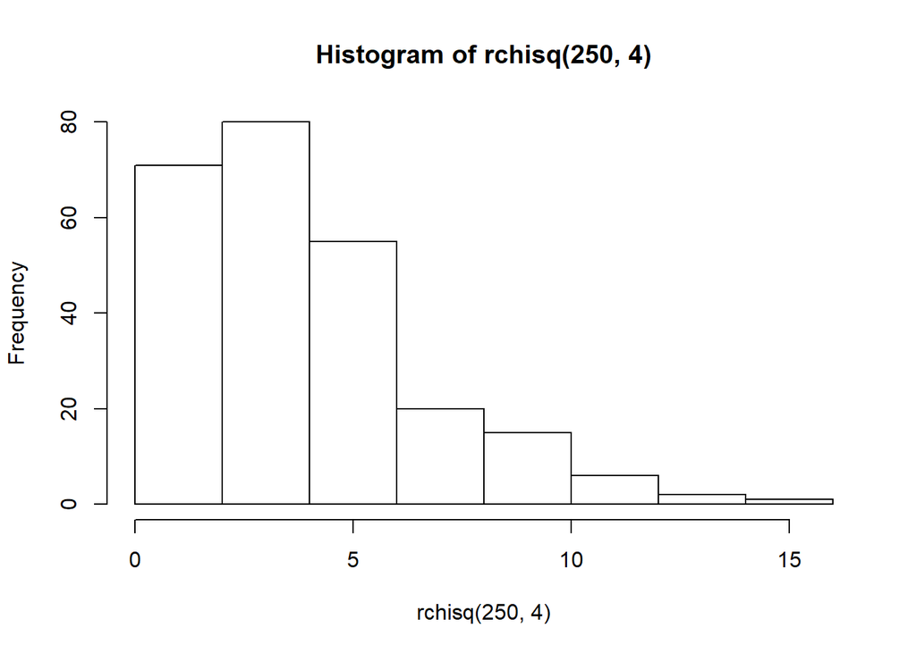

```r
hist(rchisq(250,4))
```

## Distribuição *t*

Também conhecida por distribuição t de Student, em homenagem ao então funcionário da Guinness William Gosset, um dos pioneiros no uso dessa distribuição para aperfeçoar a produção da cervejaria, a distribuição t é bastante similar à distribuição normal. De fato, conforme o tamanho amostral (e os graus de liberdade, por consequência) aumentam, mais a distribuição *t* se aproxima da distribuição *z*. No geral, contudo, a distribuição *t* possui caudas maiores, ou seja, valores mais distantes da média são mais prováveis do que na distribuição normal. Da mesma forma que a soma dos quadrados de distribuições normais formam uma distribuição $\chi^2$, a distribuição t com *n* graus de liberdade é formada quando dividimos uma distribuição normal pela raiz quadrada de um distribuição $\chi^2$ ponderada - ou seja, uma distribuição $\chi^2$ dividida pelos graus de liberdade.

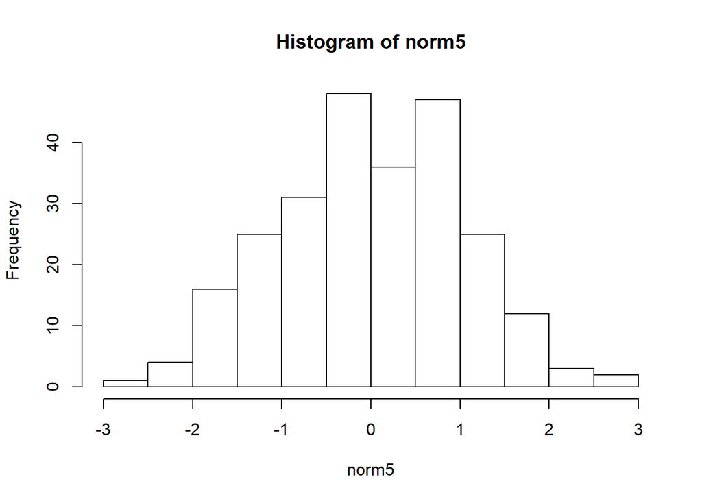

```r
set.seed(19)
norm5 <- rnorm(250,0,1)
chisq_p <- rchisq(250,4)/4
t1 <- norm5/sqrt(chisq_p)
t2 <- rt(n = 250,4)
hist(norm5)
```

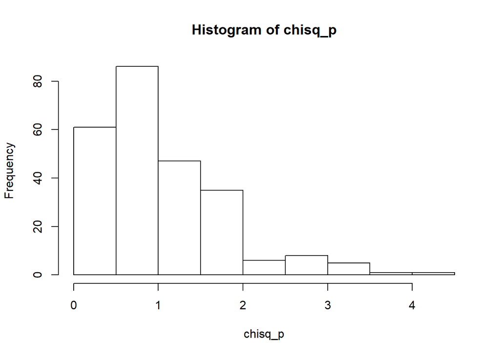

```r
hist(chisq_p)
```

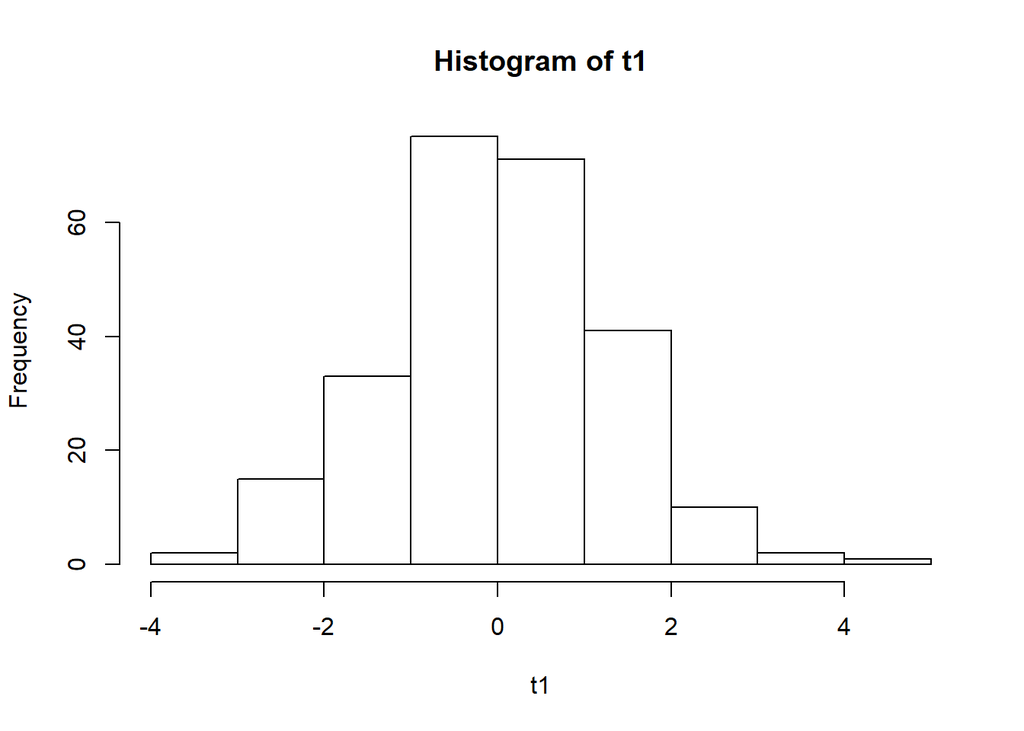

```r
hist(t1)
```

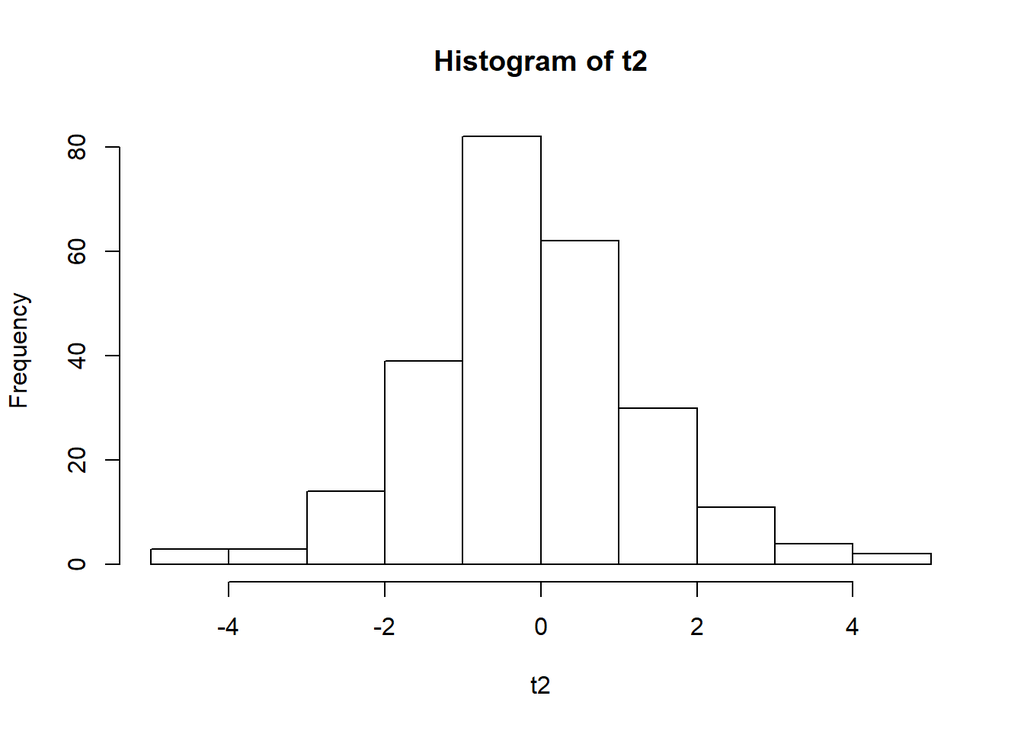

```r
hist(t2)
```